# Set 4

Alexander Williams

2024-10-02

# Skewness and Kurtosis

variability associated with random variable X is defined by:
$$VAR[X]=E[(X-E[X])^2]$$

The skewness of variable X is defined by:
$$Skew[X]=E[(\frac{X-\mu}{\sigma})^3]$$
if Skew[X] >0, than the right tail is longer.

```r
# load skew-normal package
library(sn)
```

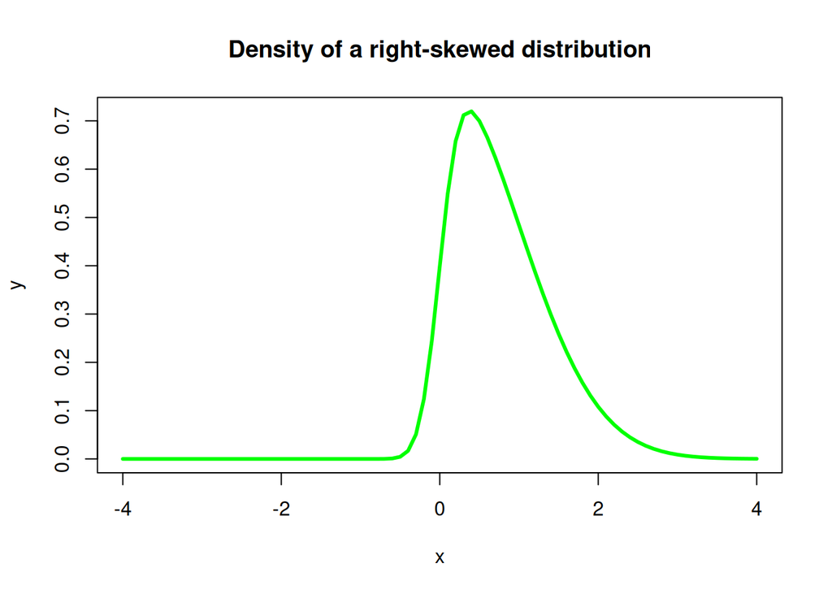

```r
# positively skewed example
x<-seq(-4,4,0.1)
y<-dsn(x,alpha=5)
plot(x,y,type='l',col='green',lwd=3)
title('Density of a right-skewed distribution')
```

If Skew[X] < 0, the left tail is longer

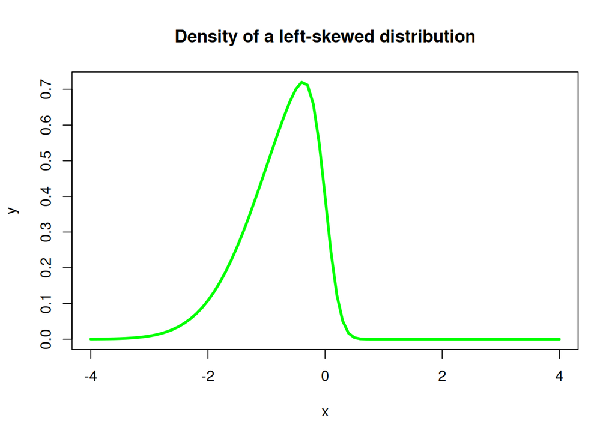

```r
x<-seq(-4,4,0.1)
y<-dsn(x,alpha=-5)
plot(x,y,type='l',col='green',lwd=3)
title('Density of a left-skewed distribution')
```

If Skew[X] = 0, the distribution is symmetric.

The Skewness can be estimated with the following equation
$$\hat{Skew}=\frac{\sum_{i=1}^n(y_i-\bar{y})^3}{ns^3}$$
we can also use this to create confidence intervals on skewness

# Example: Skewness

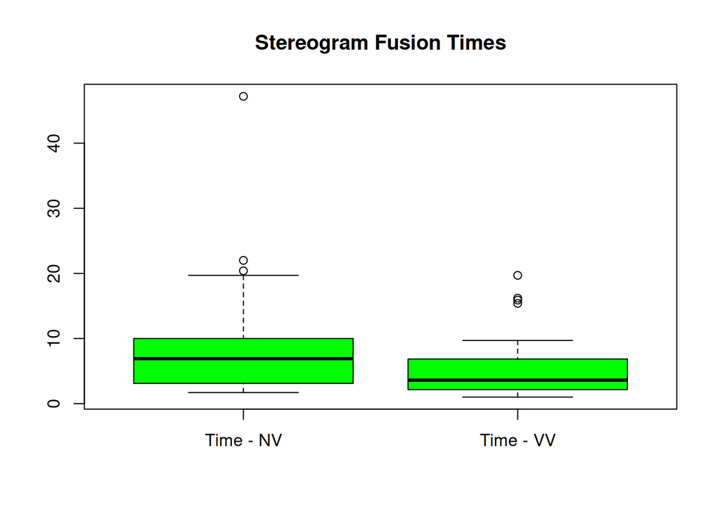

```r
stereograms<-read.table(file="~/Documents/uni/STAT359/data/stereograms.txt",
                         sep="",
                         header=TRUE)
time.NV<-stereograms$fusion_time[stereograms$group=='NV']
time.VV<-stereograms$fusion_time[stereograms$group=='VV']
boxplot(time.NV,time.VV,col='green',names=c('Time - NV','Time - VV'))
title('Stereogram Fusion Times')
```

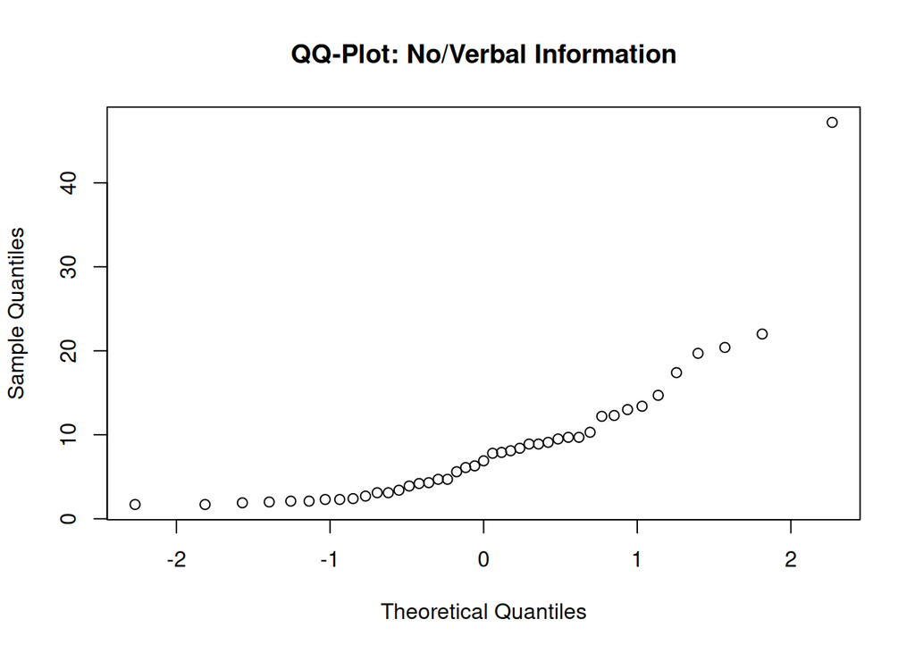

```r
qqnorm(time.NV,main='QQ-Plot: No/Verbal Information')
```

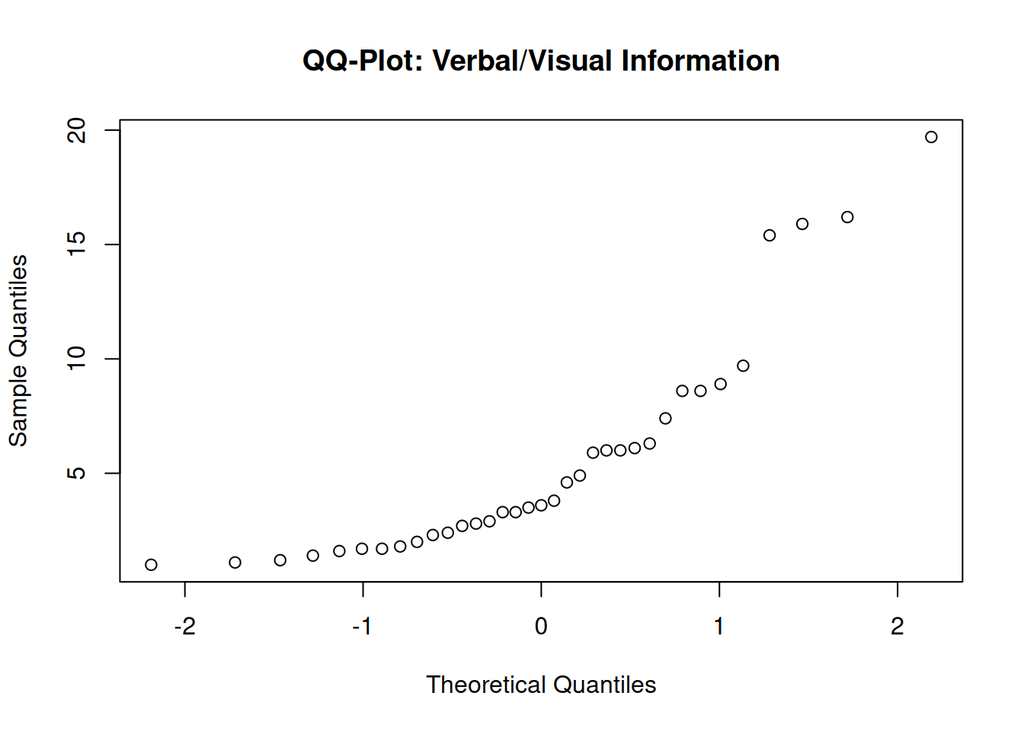

```r
qqnorm(time.VV,main='QQ-Plot: Verbal/Visual Information')
```

```r
# function to compute skewness
skew <-function(x)
{
  m3 <- sum((x-mean(x))^3)/length(x)
  s3<-sqrt(var(x))^3
  m3/s3
}
```

```r
skew.hat.NV <- skew(time.NV)
skew.hat.NV
```

```
## [1] 2.675268
```

```r
skew.hat.VV<-skew(time.VV)
skew.hat.VV
```

```
## [1] 1.417396
```

Now lets useconstruct the 95% confidence interval for skewness

```r
x<-time.NV ## data for bootstrapping
B<-15000
# Doing all samples at once via vectorization
#time.NV
x.boot<-matrix(data=sample(x=x,size=B*length(x),replace=TRUE),
               nrow=length(x),
               ncol=B)
skew.boot.sampled<-apply(x.boot,# applies function to whole matrix
                         2,     # 2 means to each column
                         skew)  # function to be used
boot.interval<-quantile(skew.boot.sampled,probs=c(0.025,0.975))
skew.hat.NV
```

```
## [1] 2.675268
```

```r
boot.interval
```

```
##      2.5%     97.5%
## 0.5527152 3.4593889
```

```r
# the above shows that 95% of the time, the skew will be between 0.57 and 3.44, positively skewed

#Time.VV
x.boot<-matrix(data=sample(x=x,size=B*length(x),replace=TRUE),nrow=length(x),ncol=B)
skew.boot.sampled<-apply(x.boot,2,skew)
boot.interval<-quantile(skew.boot.sampled,probs=c(0.025,0.975))
skew.hat.VV
```

```
## [1] 1.417396
```

```r
boot.interval
```

```
##      2.5%     97.5%
## 0.5662867 3.4537651
```

# Example - Slalom times

```r
slalom2014<-read.table(file="~/Documents/uni/STAT359/data/slalom2014.txt",
                         sep="",
                         header=TRUE)
names(slalom2014)
```

```
## [1] "Rank"       "First_Name" "Last_Name"  "Country"    "Time_sec"
## [6] "Time"
```

```r
attach(slalom2014)

summary(Time_sec)
```

```
##    Min. 1st Qu.  Median    Mean 3rd Qu.    Max.
##   165.3   167.5   173.3   177.4   184.6   217.6
```

```r
sqrt(var(Time_sec))
```

```
## [1] 11.71809
```

```r
Time.skew.est<-skew(Time_sec)
Time.skew.est
```

```
## [1] 1.12088
```

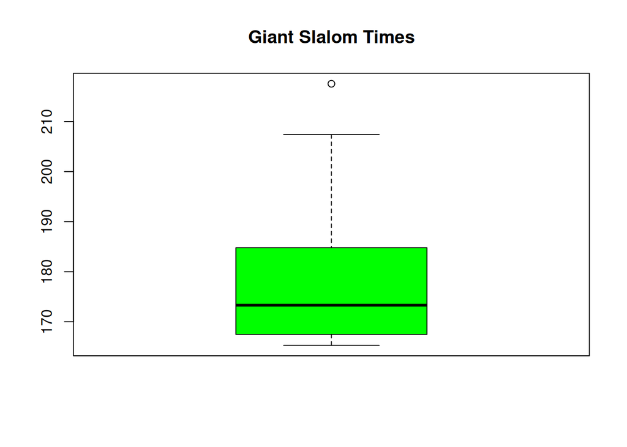

```r
boxplot(Time_sec, col='green')
title('Giant Slalom Times')
```

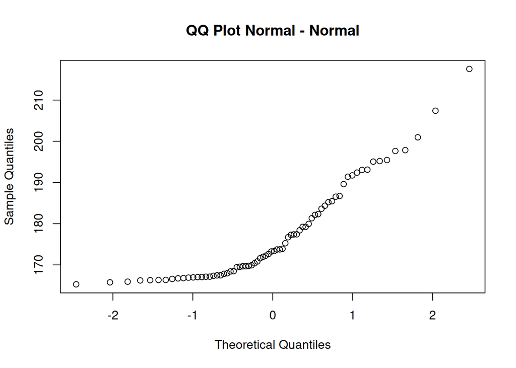

```r
qqnorm(Time_sec,main='QQ Plot Normal - Normal')
```

This data is very clearly skewed, as is common in event time data.

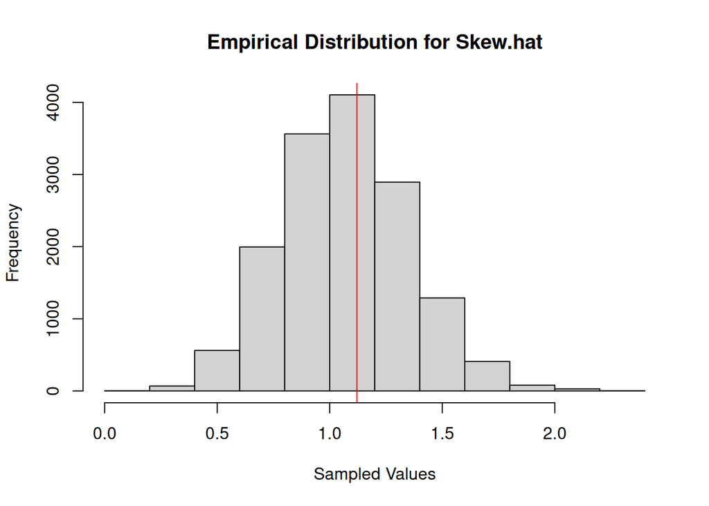

```r
x<-Time_sec ## data for bootstrapping
B<-15000
x.boot<-matrix(data=sample(x=x,size=B*length(x),
                           replace=TRUE),
               nrow=length(x),
               ncol=B)

skew.boot.sampled<-apply(x.boot, # Data to sample from
                         2,      # 2 means apply to rows, 1 means to columns
                         skew)   # function to apply
boot.interval<-quantile(skew.boot.sampled,probs=c(0.025,0.975))

hist(skew.boot.sampled,
     main='Empirical Distribution for Skew.hat',
     xlab='Sampled Values')

# Create red line showing observed median
abline(v=Time.skew.est,
       col='red') ## arguments can be a and b, h, or v
```

```r
Time.skew.est
```

```
## [1] 1.12088
```

# Kurtosis

Measure of fourth moment of distribution, measures weight of tails and how pointed/flat the peak is relative to a normal distribution.
$$Kurt[X]=E[(\frac{X-\mu}{\sigma})^4]-3$$
We can calculate sample kurtosis with:
$$\hat{Kurt}=\frac{\sum_{i=1}^n(y_i-\bar{y})^4}{ns^4}-3$$

Positive kurtosis means heavier tails, like a t-distribution

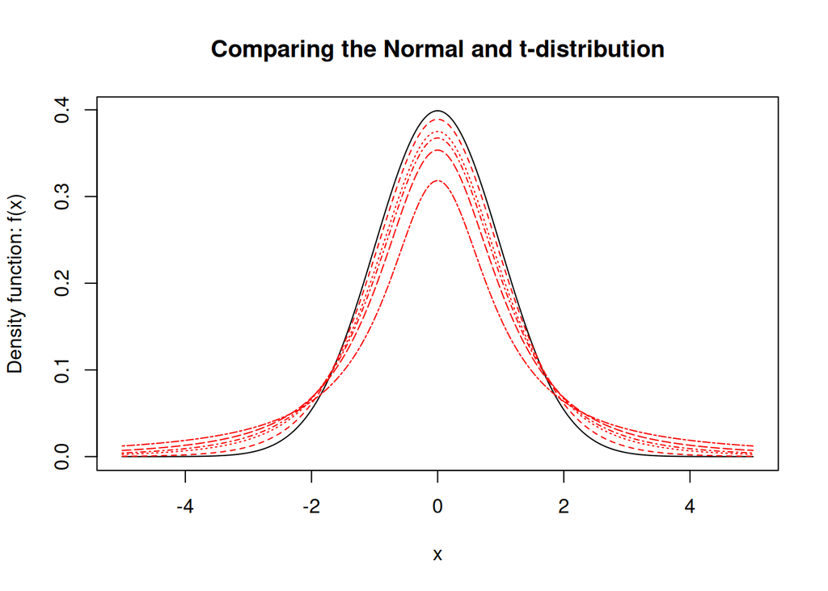

```r
x<-seq(-5,5,.01)
y.norm<-dnorm(x,mean=0,sd=1)
y.t1<-dt(x,df=1)
y.t2<-dt(x,df=2)
y.t3<-dt(x,df=3)
y.t4<-dt(x,df=4)
y.t10<-dt(x,df=10)

# set up the plot area
plot(c(min(x),max(x)),c(min(y.norm,y.t1,y.t2,y.t3,y.t4,y.t10),max(y.norm,y.t1,y.t2,y.t3,y.t4,y.t10)),type="n",
xlab="x",ylab="Density function: f(x)")
title("Comparing the Normal and t-distribution")
lines(x,y.norm)
lines(x,y.t10,lty=2,col="red")
lines(x,y.t4,lty=3,col="red")
lines(x,y.t3,lty=4,col="red")
lines(x,y.t2,lty=5,col="red")
lines(x,y.t1,lty=6,col="red")
```

Negative kurtosis means lighter tails, and often a flatter shape. A uniform distribution is a good example

Function to estimate kurtosis

```r
kurtosis<-function(x)
  {
  m4<-sum((x-mean(x))^4)/length(x)
  s4<-var(x)^2
  m4/s4 - 3
  }
```

What values to you get with a normal distribution? We expect 0

```r
x.norm <- rnorm(1000)
x.norm.kurt <- kurtosis(x.norm)
x.norm.kurt
```

```
## [1] -0.1977785
```

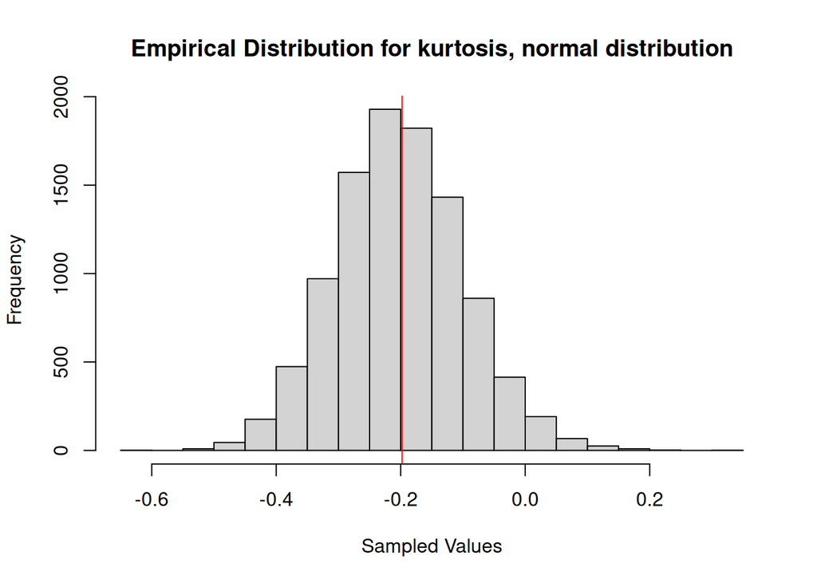

```r
# We can bootstrap it to get a confidence interval for the kurtosis
x <- x.norm # data to bootstrap
B <- 10000 # times to bootstrap

x.boot <- matrix(data=sample(x=x,size=B*length(x),replace=TRUE),
                 nrow=length(x),
                 ncol=B)
x.boot.kurt <- apply(x.boot,
                     2,
                     kurtosis)
boot.interval <- quantile(x.boot.kurt,
                          probs=c(0.025, 0.975))
hist(x.boot.kurt, main='Empirical Distribution for kurtosis, normal distribution',xlab='Sampled Values')
abline(v=x.norm.kurt, col='red') ## arguments can be a and b, h, or v
```

The value varies every time it’s run, but should be very close to zero on average. Lets do the same steps again, but with a t-distribution

```r
x.t <- rt(1000, df=4)
x.t.kurt <- kurtosis(x.t)
x.t.kurt
```

```
## [1] 4.92154
```

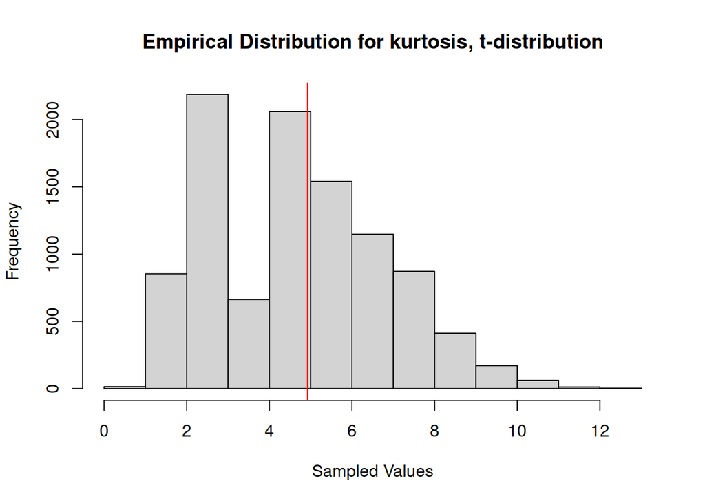

```r
# bootstrap
x <- x.t
B <- 10000 # times to bootstrap

x.boot <- matrix(data=sample(x=x,size=B*length(x),replace=TRUE),
                 nrow=length(x),
                 ncol=B)
x.boot.kurt <- apply(x.boot,
                     2,
                     kurtosis)
boot.interval <- quantile(x.boot.kurt,
                          probs=c(0.025, 0.975))
hist(x.boot.kurt, main='Empirical Distribution for kurtosis, t-distribution',xlab='Sampled Values')
abline(v=x.t.kurt, col='red') ## arguments can be a and b, h, or v
```

This is much higher than the normal distribution, implying excess kurtosis compared to the normal distribution.

What a higher kurtosis means is that data is less likely to be near the mean. Greater kurtosis means it’s more likely to see an extreme result

# Example: stereograms

```r
kurt.time.NV <- kurtosis(time.NV)
kurt.time.VV <- kurtosis(time.VV)
kurt.time.NV
```

```
## [1] 9.66402
```

```r
kurt.time.VV
```

```
## [1] 1.160395
```

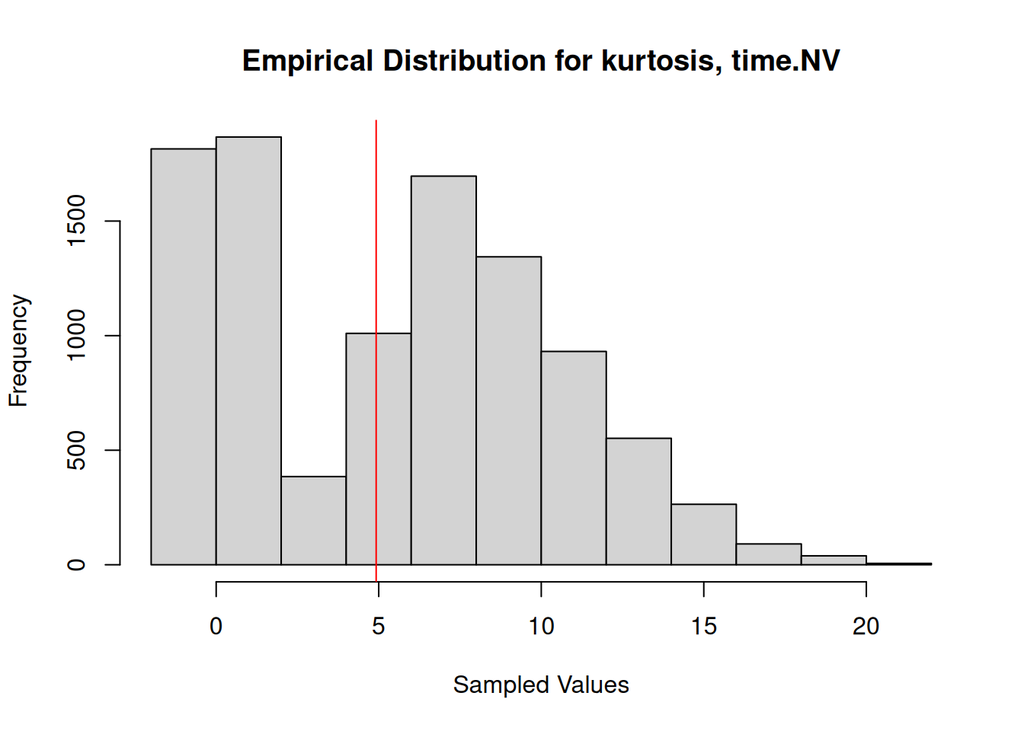

```r
# Is that a very large kurtosis, or is there too much uncertainly due to small sample size? lets bootstrap
x <- time.NV
B <- 10000 # times to bootstrap

x.boot <- matrix(data=sample(x=x,size=B*length(x),replace=TRUE),
                 nrow=length(x),
                 ncol=B)
x.boot.kurt <- apply(x.boot,
                     2,
                     kurtosis)
boot.interval <- quantile(x.boot.kurt,
                          probs=c(0.025, 0.975))
hist(x.boot.kurt, main='Empirical Distribution for kurtosis, time.NV',xlab='Sampled Values')
abline(v=x.t.kurt, col='red') ## arguments can be a and b, h, or v
```

```r
boot.interval
```

```
##       2.5%      97.5%
## -0.8081172 14.9459851
```

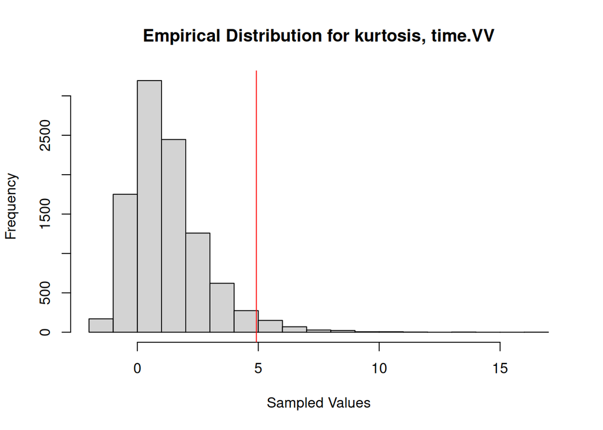

```r
x <- time.VV
B <- 10000 # times to bootstrap

x.boot <- matrix(data=sample(x=x,size=B*length(x),replace=TRUE),
                 nrow=length(x),
                 ncol=B)
x.boot.kurt <- apply(x.boot,
                     2,
                     kurtosis)
boot.interval <- quantile(x.boot.kurt,
                          probs=c(0.025, 0.975))
hist(x.boot.kurt, main='Empirical Distribution for kurtosis, time.VV',xlab='Sampled Values')
abline(v=x.t.kurt, col='red') ## arguments can be a and b, h, or v
```

```r
boot.interval
```

```
##       2.5%      97.5%
## -0.9150395  5.1583957
```

The interval is much smaller, and also contains 0 so we have no evidence that the kurtosis is not normal